# PLSC 468 Final Project

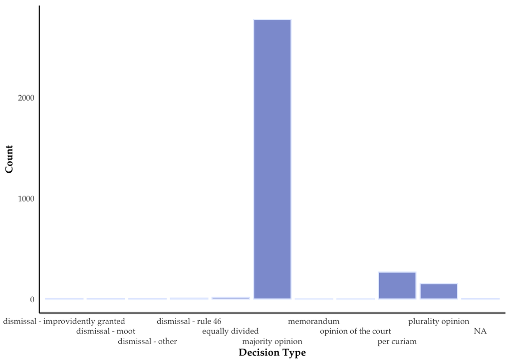

```r
ggplot(dat, aes(x=decision_type)) +
  geom_bar(fill="#8D9DD5", color="#E3EBFF") +
  theme_minimal() +
  xlab("Decision Type") +
  scale_x_discrete(guide = guide_axis(n.dodge=3)) +
  ylab("Count") +
  theme(
    axis.line = element_line(colour = "black"),
    panel.grid.major = element_blank(),
    panel.grid.minor = element_blank(),
    panel.border = element_blank(),
    panel.background = element_blank(),
    text = element_text(family = "Palatino", size = 10),
    axis.title.y = element_text(face = "bold"),
    axis.title.x = element_text(face = "bold"),
  )
```

We note the vast majority of the Court’s decisions are majority opinions, where more than half of the Court agrees on the decision and the reasoning. A plurality opinion has the greatest number of votes but not necessarily a majority and is not binding. These opinions typically have 1 justice as the author. In contrast, per curiam opinions do not identify an author and are opinions of the Court.

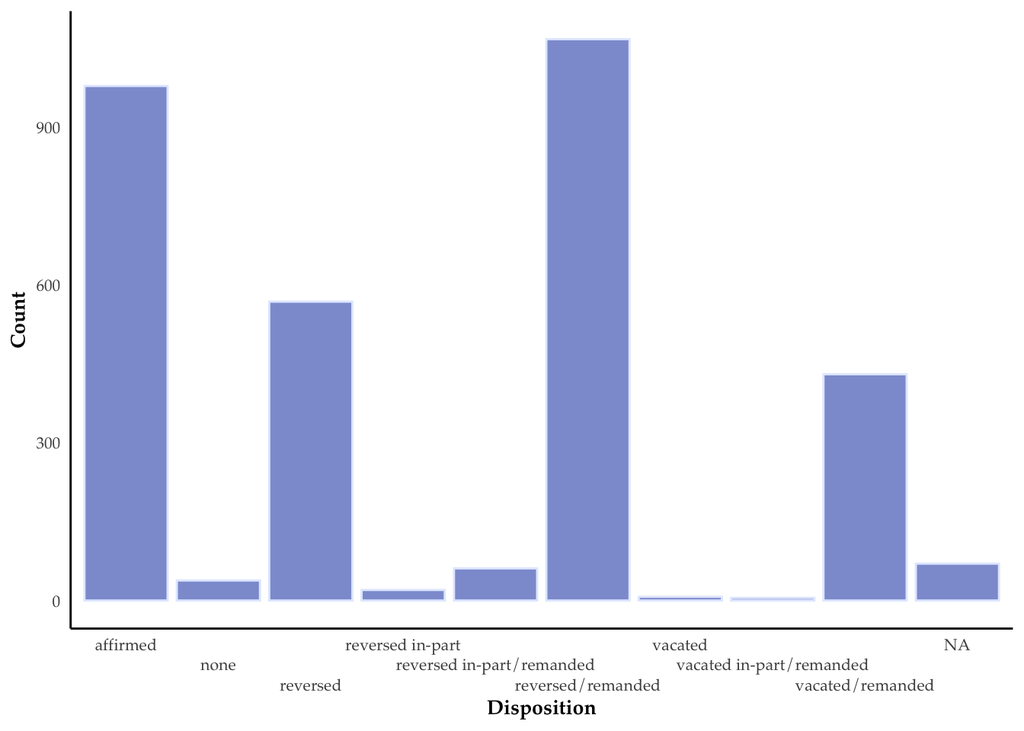

```r
ggplot(dat, aes(x=disposition)) +
  geom_bar(fill="#8D9DD5", color="#E3EBFF") +
  theme_minimal() +
  xlab("Disposition") +
  scale_x_discrete(guide = guide_axis(n.dodge=3)) +
  ylab("Count") +
  theme(
    axis.line = element_line(colour = "black"),
    panel.grid.major = element_blank(),
    panel.grid.minor = element_blank(),
    panel.border = element_blank(),
    panel.background = element_blank(),
    text = element_text(family = "Palatino", size = 10),
    axis.title.y = element_text(face = "bold"),
    axis.title.x = element_text(face = "bold"),
  )
```

We note a variety of decision types: interestingly, the court affirms a decision about as often as it reverses/remands a decision.

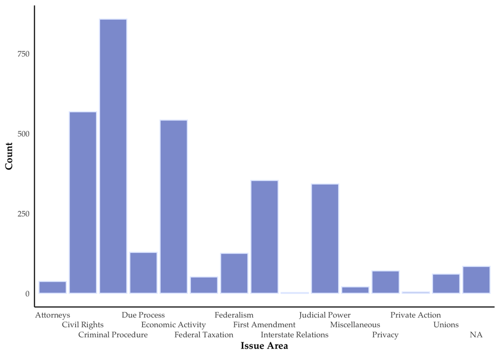

```r
ggplot(dat, aes(x=issue_area)) +
  geom_bar(fill="#8D9DD5", color="#E3EBFF") +
  theme_minimal() +
  xlab("Issue Area") +
  scale_x_discrete(guide = guide_axis(n.dodge=3)) +
  ylab("Count") +
  theme(
    axis.line = element_line(colour = "black"),
    panel.grid.major = element_blank(),
    panel.grid.minor = element_blank(),
    panel.border = element_blank(),
    panel.background = element_blank(),
    text = element_text(family = "Palatino", size = 10),
    axis.title.y = element_text(face = "bold"),
    axis.title.x = element_text(face = "bold"),
  )
```

We note a variety of issue areas, particularly Civil Rights, Criminal Procedure, and Economic Activity.